# Test a Perceptual Phenomenon - Stroop Effect

## Background

In psychology, the [Stroop effect](https://en.wikipedia.org/wiki/Stroop_effect) is a demonstration of interference in the reaction time of a task. When the name of a color (e.g., "blue", "green", or "red") is printed in a color that is not denoted by the name (e.g., the word "red" printed in blue ink instead of red ink), naming the color of the word takes longer and is more prone to errors than when the color of the ink matches the name of the color. The effect is named after John Ridley Stroop, who first published the effect in English in 1935.

In a Stroop task, participants are presented with a list of words, with each word displayed in a color of ink. The participant’s task is to say out loud the color of the ink in which the word is printed. The task has two conditions: a congruent words condition, and an incongruent words condition. In the congruent words condition, the words being displayed are color words whose names match the colors in which they are printed: for example RED, BLUE. In the incongruent words condition, the words displayed are color words whose names do not match the colors in which they are printed: for example PURPLE, ORANGE. In each case, we measure the time it takes to name the ink colors in equally-sized lists. Each participant will go through and record a time from each condition.

## Questions For Investigation

### 1. What is our independent variable? What is our dependent variable?

Independent Variable: word condition, whether the word is congruent or incongruent. Depedent Variable: respond time in seconds.

### 2. What is an appropriate set of hypotheses for this task? What kind of statistical test do you expect to perform? Justify your choices.

The null hypothesis can be that there is no significant difference in the population average amount of time it takes to state the colors of the words of the congruent and incongruent conditions, in this case it's a two-tailed test. The alternative hypothesis can be that there is a significant difference, positive or negative, in the population average response times. So,

$H_0: \mu_C = \mu_I$

$H_A: \mu_C \neq \mu_I$

"C" represents the congruent words condition, and "I" represents the incongruent words condition.

We are referring to the population means of congruence words group and incongruence words group, means the average time in seconds for the respective groups to recongnize the colors. By comparing these means directly, we'll be able to tell whether these is a difference d=between the two groups' color recognition time. However, it wouldn't be possible to do the expieriment with all potential subjects around the world, so we work with the sample on hand to make inference about the population means, for example, to use the observation means, std and other statistics to infer about the pupulation means. In this case, the observation is the difference between the two group's time.

Here a two-tailed, dependent samples t-test should be performed. Because the population variance is unknown and the sample size is less than 30. When the sample size is less than 30, the sample data is no longer approximate a normal distribution, and it makes the use of a Z value not that appropriate.

### 3. Report some descriptive statistics regarding this dataset. Include at least one measure of central tendency and at least one measure of variability.

```python
import pandas
df = pandas.read_csv('C:/Files/Udacity/Data-Analysis/Projects/Test a Perceptual Phenomenon - Stroop Effect/stroopdata.csv')
df
```

|  | Congruent | Incongruent |
| --- | --- | --- |
| 0 | 12.079 | 19.278 |
| 1 | 16.791 | 18.741 |
| 2 | 9.564 | 21.214 |
| 3 | 8.630 | 15.687 |
| 4 | 14.669 | 22.803 |
| 5 | 12.238 | 20.878 |
| 6 | 14.692 | 24.572 |
| 7 | 8.987 | 17.394 |
| 8 | 9.401 | 20.762 |
| 9 | 14.480 | 26.282 |
| 10 | 22.328 | 24.524 |
| 11 | 15.298 | 18.644 |
| 12 | 15.073 | 17.510 |
| 13 | 16.929 | 20.330 |
| 14 | 18.200 | 35.255 |
| 15 | 12.130 | 22.158 |
| 16 | 18.495 | 25.139 |
| 17 | 10.639 | 20.429 |
| 18 | 11.344 | 17.425 |
| 19 | 12.369 | 34.288 |
| 20 | 12.944 | 23.894 |
| 21 | 14.233 | 17.960 |
| 22 | 19.710 | 22.058 |
| 23 | 16.004 | 21.157 |

```python
df.describe().transpose()
```

|  | count | mean | std | min | 25% | 50% | 75% | max |
| --- | --- | --- | --- | --- | --- | --- | --- | --- |
| Congruent | 24.0 | 14.051125 | 3.559358 | 8.630 | 11.89525 | 14.3565 | 16.20075 | 22.328 |
| Incongruent | 24.0 | 22.015917 | 4.797057 | 15.687 | 18.71675 | 21.0175 | 24.05150 | 35.255 |

```python
from scipy import stats
c = df['Congruent']
i = df['Incongruent']
c_se = stats.sem(c)
i_se = stats.sem(i)
print (c_se)
print (i_se)
```

```
0.726550900679
0.979195184753
```

**Summary**

| Statistic | Congruent | Incongruent |
| --- | --- | --- |
| n | 24 | 24 |
| $\bar{x}$ | 14.05 | 22.02 |
| Median | 14.36 | 21.02 |
| std | 3.56 | 4.80 |
| SE | 0.73 | 0.98 |

### 4. Provide one or two visualizations that show the distribution of the sample data. Write one or two sentences noting what you observe about the plot or plots.

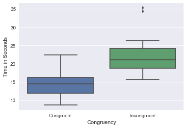

```python
import seaborn as sns
%matplotlib inline

sns.boxplot(data=df)
plt.ylabel('Time in Seconds')
plt.xlabel('Congruency')
```

The boxplot indicates that the two groups have significant difference in median times, and the two groups also have different ranges, with the "Incongruent" words group showing much longer times.

### 5. Now, perform the statistical test and report your results. What is your confidence level and your critical statistic value? Do you reject the null hypothesis or fail to reject it? Come to a conclusion in terms of the experiment task. Did the results match up with your expectations?

$Confidence level = 99%$

$\alpha = .01$

$df = 23$

$t_{critical} = \pm 2.807$

$t = -8.02$

$p-value = <.0001$

So at the 99% confidence level ($\alpha$) and 23 degrees of freedom, the critical statistic value of a two-tailed test in the negative direction is $\pm 2.807$. The calculated t-statistic for the difference in stoop effect test time in seconds is -8.02. Since the t-statistic is in the critical region and the p-value is less than 0.05, the null hypothesis is rejected.

There is sufficient evidence at the α = .01 level of significance to support the claim that that the difference between congruence and incongruence group time difference is statistically significant, namely, the stroop effect is present.

### 6. Optional: What do you think is responsible for the effects observed? Can you think of an alternative or similar task that would result in a similar effect? Some research about the problem will be helpful for thinking about these two questions!

In my opinion, this effect is caused by the distraction resulted from the presence of the words and particularly, the wrongly labled words. Since humans are so sensitive to words that there is already a “conditioned reflex” established. Therefore, whenever a a word is present, eyes and brain will automatically capture and deciper them, which leads to a delay and a interference with the color recognition.

As per Wikipedia, “Warped words”" is a similiar situation. A similiear experiment involving hard to read words can be used to test the effect.

## Reference

https://docs.scipy.org/doc/scipy-0.14.0/reference/generated/scipy.stats.sem.html

https://math.meta.stackexchange.com/questions/5020/mathjax-basic-tutorial-and-quick-reference

https://en.wikipedia.org/wiki/Stroop_effect

http://assemble.io/docs/Cheatsheet-Markdown.html